# Project3

Nicholas Kunze, Naomi Buell, Kaylie Evans

2024-03-15

## Load Database

Get normalized database from MySQL server and browse.

```r
azuredb = dbConnect(MySQL(), user=params$dbuser, password=params$dbpass, dbname=params$dbname, host=params$dbhost)

jobs <- dbGetQuery(azuredb,
  "SELECT
      j.id as id, t.title as title, c.cname as company, o.val as onsite_remote,
        j.descr as `description`, j.salary as salary, j.location as location, j.criteria as criteria,
        j.posted as posted, j.link as link
   FROM
      jobs j, job_title t, company c, onsite_remote o
   WHERE
      j.title = t.id AND j.cid = c.id AND j.orid = o.id;")
head(jobs)
```

```
##   id                          title company onsite_remote
## 1  1                   Data Analyst  PayPal        onsite
## 2  2                   Data Analyst  PayPal        onsite
## 3  3                   Data Analyst  PayPal        onsite
## 4  4 Data Analyst - Recent Graduate  PayPal        onsite
## 5  5                   Data Analyst  PayPal        onsite
## 6  6                   Data Analyst  PayPal        onsite
##                                                                                                                                                                                                                                                                                                          …
## 1 At PayPal (NASDAQ: PYPL), we believe that every person has the right to participate fully in the global economy. Our mission is to democratize financial services to ensure that everyone, regardless of background or economic standing, has access to affordable, convenient, and secure products and…
## 2 At PayPal (NASDAQ: PYPL), we believe that every person has the right to participate fully in the global economy. Our mission is to democratize financial services to ensure that everyone, regardless of background or economic standing, has access to affordable, convenient, and secure products and…
## 3 At PayPal (NASDAQ: PYPL), we believe that every person has the right to participate fully in the global economy. Our mission is to democratize financial services to ensure that everyone, regardless of background or economic standing, has access to affordable, convenient, and secure products and…
## 4                                                                                                                                                                                                                                                                                                        …
## 5 At PayPal (NASDAQ: PYPL), we believe that every person has the right to participate fully in the global economy. Our mission is to democratize financial services to ensure that everyone, regardless of background or economic standing, has access to affordable, convenient, and secure products and…
## 6 At PayPal (NASDAQ: PYPL), we believe that every person has the right to participate fully in the global economy. Our mission is to democratize financial services to ensure that everyone, regardless of background or economic standing, has access to affordable, convenient, and secure products and…
##   salary                 location
```

[output cut: 27 more lines]

## Tidy Description

Prepare to find skills as listed in `skills_list_str` in the `description` variable.

```r
skills_list_str <-
  'python,r,sql,machine learning,data mining,data visualization,big data,sql,nosql,hadoop,spark,statistics,a/b,cleaning,data warehouse,etl,data lake,communication,teamwork,sklearn,scikit,pandas,numpy,tensorflow,keras,pytorch,database,mysql,postgresql,oracle,mongo,cloud,aws,azure,google cloud,git,deep learning,dnn,neural network,powerbi,tableau,teradata,javascript,airflow,linux,perl,java,php,bachelor,master,phd,doctorate'
skills_list <- strsplit(skills_list_str, split = ",", fixed = TRUE)[[1]]
jobs[, 'skills'] = ""
```

Iterate over job descriptions and check for skill.

```r
for (row in 1:nrow(jobs)) {
  job <- jobs[row, ]
  desc <- tolower(job$description)
  for (skill in skills_list) {
    if (grepl(skill, desc, fixed = TRUE)) {
      jobs[row, ]$skills <- paste(jobs[row, ]$skills, skill, ",")
    }
  }
}
```

Create normalized table of skills mapped to unique job ID in `jobs` data frame.

```r
jobs.skills <- jobs %>%
  pivot_longer(skills) %>%
  mutate(value = strsplit(as.character(value), ",")) %>%
  unnest(value) %>%
  group_by(id, value) %>%
  summarize(value = unique(value), .groups = "drop") %>%
  as.data.frame()
head(jobs.skills)
```

```
##   id      value
## 1  1  database
## 2  1       git
## 3  1    hadoop
## 4  1    python
## 5  1         r
## 6  1       sql
```

## Tidy Criteria

Split up `criteria` variable to create separate variables for seniority, employment type, job function, and industry.

```r
jobs <- jobs %>%
    mutate(seniority = str_extract(criteria, "(?<='Seniority level': ')(.*?)(?='\\})"))
jobs <- jobs %>%
    mutate(etype = str_extract(criteria, "(?<='Employment type': ')(.*?)(?='\\})"))
jobs <- jobs %>%
    mutate(jfunction = str_extract(criteria, "(?<='Job function': ')(.*?)(?='\\})"))
jobs <- jobs %>%
    mutate(industries = str_extract(criteria, "(?<='Industries': ')(.*?)(?='\\})"))
```

Normalized table of industries mapped to unique job ID in `jobs` data frame.

```r
jobs.industries <- jobs %>%
  pivot_longer(industries) %>%
  mutate(value = strsplit(as.character(value), ",")) %>%
  unnest(value) %>%
  group_by(id, value) %>%
  summarize(value = unique(value), .groups = "drop") %>%
  as.data.frame()
jobs.industries <- jobs.industries %>%
  mutate(across('value', ~str_remove_all(., 'and ')))
```

## Tidy Title

List of unique raw titles below. All are data analysts. Some job titles have other information included in the field (e.g., remote/hybrid information).

```r
unique(jobs$title)
```

```
##  [1] "Data Analyst"
##  [2] "Data Analyst - Recent Graduate"
##  [3] "Entry-Level Data Analyst"
##  [4] "Analyst (Global Data and Analytics)"
##  [5] "Data Analyst/Collector"
##  [6] "Data Analytics Analyst"
##  [7] "Data Analyst, Money"
##  [8] "Data Analyst I"
##  [9] "Entry Level Data Analyst"
## [10] "Data Analyst - Remote"
## [11] "Data Analyst III - Remote"
## [12] "WFH//Data Analyst"
## [13] "Data Analyst (SQL)"
## [14] "Data Analyst - remote!"
## [15] "SQL Data Analyst"
```

[output cut: 21 more lines]

To be tidy, every cell can only have one piece of information. To this end, pull out remote/hybrid details from “title”. As a check, we verify that this info matches with the existing “onsite_remote” column.

```r
jobs <- jobs |>
  # pull extra detail from "tite" to variable "analyst_detail"
  mutate(
    analyst_detail = title |>
      str_remove("Data Analyst") |>
      str_remove("Data analyst") |>
      str_remove(" - ") |>
      str_trim(),
    # pull details into new column for onsite_remote for QC
    analyst_detail_onsite_remote = str_detect(analyst_detail, "Remote") |
      str_detect(analyst_detail, "remote") |
      str_detect(analyst_detail, "Hybrid") |
      str_detect(analyst_detail, "REMOTE") |
      str_detect(analyst_detail, "WFH") |
      str_detect(analyst_detail, "Onsite"),
    # Remove these details and more from our list of details using REGEX
    title_clean = title |>
      str_replace("analyst", "Analyst") |> # standardize capitalization
      str_remove("Remote") |> # remove remote/onsite qualifiers
      str_remove("remote") |>
      str_remove("Hybrid") |>
      str_remove("REMOTE") |>
      str_remove("WFH") |>
      str_remove("Onsite")|>
      str_remove("Weekly.*Schedule") |>
      str_remove("\\(.*\\)") |> # remove parentheticals
      str_remove("\\/.*\\/") |> # remove content within slashes
      str_remove("//") |> # remove other symbols to standardize
      str_remove("!") |>
      str_remove("- $") |>
      str_replace("  "," ") |>
      str_trim() |>
      as.factor()
  )
```

Here are all the values in my cleaned titles column:

```r
levels(jobs$title_clean)
```

```
##  [1] "Analyst"                         "Analyst - Data Visualization"
##  [3] "Analyst, Data and Analytics"     "Associate Data Analyst"
##  [5] "Business Data Analyst"           "Consultant/Data Analyst"
##  [7] "Data Analyst"                    "Data Analyst - Energy"
##  [9] "Data Analyst - Recent Graduate"  "Data Analyst I"
## [11] "Data Analyst III"                "Data Analyst, Money"
## [13] "Data Analyst/Collector"          "Data Analytics Analyst"
## [15] "Data Visualization Analyst"      "Entry Level Data Analyst"
## [17] "Entry-Level Data Analyst"        "Group Data Analyst"
## [19] "Junior Data Analyst"             "Junior Data Analyst-Entry Level"
## [21] "Marketing Data Analyst"          "Senior Data Analyst"
## [23] "SQL Data Analyst"
```

As a check, I browsed the data to verify that remote/onsite job title qualifiers matched with specifications in the `remote_onsite` column. Everything looks consistent:

```r
jobs_onsite_check <- jobs |>
  filter(analyst_detail_onsite_remote) |>
  select(title, onsite_remote) |>
  unique()

head(jobs_onsite_check, nrow(jobs_onsite_check))
```

```
##                                                  title onsite_remote
## 1                                Data Analyst - Remote        remote
## 3                            Data Analyst III - Remote        remote
## 4                                    WFH//Data Analyst        remote
## 5                               Data Analyst - remote!        remote
## 19                        Data Analyst (Global Remote)        remote
## 21                        Data Analyst - (Remote - US)        remote
## 83                               Data Analyst (Remote)        remote
## 85               REMOTE Data Analyst (SQL, Operations)        remote
## 88  Data Analyst (SQL, Teraform, Tableau) III - Remote        remote
## 89                               Data Analyst (Hybrid)        hybrid
## 90 Data Analyst - Weekly Hybrid Remote/Onsite Schedule        hybrid
## 91               Data Analyst/ $100M Valuation/ Hybrid        hybrid
```

## Clean Location

Next we work with location, which contains data with varying levels of granularity (e.g., some at state level, some at city level). We make columns consistent by separating data into state and location columns. We split `location` column into two separate columns–one for city and one for state below:

```r
jobs <- jobs |>
  mutate(
    location_1 = str_extract(location, "[^,]+"),
    # get location before the comma, typically city
    location_2 = str_extract(location, "(?<=,\\s).+") # use REGEX to get location after the comma, typically state
  )
```

We use the built in R data set to ensure the `state` variable is consistent; we use state abbreviations throughout. I also manually fix one city-state combination (Columbus, South Carolina Metropolitan Area to Columbus, SC).

```r
# get state names and abbreviations from built-in dataset
states <- data.frame(state.abb, state.name) |>
  rename(location_1 = state.name)

jobs <- jobs |>
  left_join(states) |> # join to get state abbrevs
  mutate(
    # gen state (abbreviation) variable
    state = if_else(location_2 == "United States", state.abb, location_2) |>
      as.factor(),

    city = if_else(is.na(state.abb) |
                     location_2 != "United States", location_1, NA) |>
      as.factor()
  ) |>
  # fix South Carolina Metropolitan Area incorrect state
  mutate(state = if_else(state == "South Carolina Metropolitan Area", "SC", state) |>
           as.factor())
```

Here are the unique cities and states in which jobs were posted:

```r
levels(jobs$city)
```

```
##  [1] "Alpharetta"
##  [2] "Ann Arbor"
##  [3] "Annapolis"
##  [4] "Atlanta"
##  [5] "Atlanta Metropolitan Area"
##  [6] "Austin"
##  [7] "Bellevue"
##  [8] "Boston"
##  [9] "Bridgewater"
## [10] "Buffalo-Niagara Falls Area"
## [11] "Burbank"
## [12] "Camden"
## [13] "Carlsbad"
## [14] "Cedar Rapids"
## [15] "Charlotte"
```

[output cut: 84 more lines]

And here are the unique states:

```r
levels(jobs$state)
```

```
##  [1] "AL" "AZ" "CA" "CT" "DC" "DE" "FL" "GA" "IA" "IL" "IN" "KS" "MA" "MD" "MI"
## [16] "MN" "MO" "MS" "NC" "NE" "NJ" "NY" "OH" "OK" "PA" "SC" "TN" "TX" "VA" "WA"
## [31] "WI"
```

## Check Company

Browsing companies for opportunities for standardization. It appears that this column is OK as is.

```r
head(jobs |> select(company) |> unique())
```

```
##                           company
## 1                          PayPal
## 29       The Federal Savings Bank
## 31                London Approach
## 33                    Motley Rice
## 34 Chicago Teachers' Pension Fund
## 36                    FreightPlus
```

## Clean Onsite/Remote

Browsing `onsite_remote` column for opportunities for standardization. The values are OK and converted to a factor variable.

```r
jobs <- jobs  |>
  mutate(onsite_remote = as.factor(onsite_remote))

levels(jobs$onsite_remote)
```

```
## [1] "hybrid" "onsite" "remote"
```

## Clean and Tidy Salary

1- find what rows are missing salary ranges 2- find what fields have salary information 3- split the salary column into 2 columns for range 4- move salary information for the rows that contain the information in other rows 5- reformat the hourly wages to salary numbers

### Step 1: Find what rows are missing salary information

```r
#only missing salaries
salary_finder_02 <- jobs |>
  filter(
    salary == NaN
  )
```

### Step 2: Find what fields have salary ranges

It is helpful to know which fields have salary information. Since the original columns have the information that were split wider to give new columns, we will only search the original columns.

```r
#title
count(
  salary_finder_02 |>
  mutate(
    title = str_extract_all(title, "salary")
  ) |>
        filter(
          title == "salary"
        )
)
```

```
##   n
## 1 0
```

```r
count(
salary_finder_02 |>
  mutate(
    title = str_extract_all(title, "$")
  ) |>
      filter(
      title == "$"
      )
)
```

```
##   n
## 1 0
```

```r
#company
count(
  salary_finder_02 |>
  mutate(
    company = str_extract_all(company, "salary")
  ) |>
      filter(
        company == "salary"
      )
)
```

```
##   n
## 1 0
```

```r
count(
salary_finder_02 |>
  mutate(
    company = str_extract_all(company, "$")
  ) |>
      filter(
      company == "$"
      )
)
```

```
##   n
## 1 0
```

```r
#description
count(
  salary_finder_02 |>
  mutate(
    description = str_extract_all(description, "salary")
  ) |>
      filter(
        description == "salary"
      )
)
```

```
##     n
## 1 151
```

```r
count(
salary_finder_02 |>
  mutate(
    description = str_extract_all(description, "$")
  ) |>
      filter(
      description == "$"
      )
)
```

```
##   n
## 1 0
```

```r
#location
count(
  salary_finder_02 |>
  mutate(
    location = str_extract_all(location, "salary")
  ) |>
      filter(
        location == "salary"
      )
)
```

```
##   n
## 1 0
```

```r
count(
salary_finder_02 |>
  mutate(
    location = str_extract_all(location, "$")
  ) |>
      filter(
      location == "$"
      )
)
```

```
##   n
## 1 0
```

```r
#criteria
count(
  salary_finder_02 |>
  mutate(
    criteria = str_extract_all(criteria, "salary")
  ) |>
      filter(
        criteria == "salary"
      )
)
```

```
##   n
## 1 0
```

```r
count(
salary_finder_02 |>
  mutate(
    criteria = str_extract_all(criteria, "$")
  ) |>
      filter(
      criteria == "$"
      )
)
```

```
##   n
## 1 0
```

The only salary information looks to be in the description with the words salary.

### Step 3: split the salary column into 2 columns for range

```r
jobs <- jobs |>
  mutate(
    sal_high = str_extract(salary, "(?<=-).*"),
    .after = salary
  ) |>
      mutate(
        sal_low = str_extract(salary, ".*(?=-)"),
        .before = sal_high
      )
```

### Step 4: move salary information for the rows that contain the information in other rows

```r
jobs <- jobs |>
  mutate(
    key_field = c(1:2845),
    .before = title
  )

#rows where salary information is already available
salary_exist <- jobs |>
  filter(
    salary != NaN
  )

#rows where there is no salary information
salary_finder_01 <- jobs |>
  filter(
    salary == NaN
  )

#filling all available salaries from description
salary_finder_03 <- salary_finder_01 |>
  mutate(
    description_02 = str_extract_all(description, "(Salary.*\\d+[,]\\d+)|(salary.*\\d+[,]\\d+)"),
    .before = "description"
  ) |>
      filter(
        description_02 != "character(0)"
      ) |>
          mutate(
            description_03 = as.character(str_extract_all(description_02, "\\d+[,]\\d+")),
            .before = "description"
          ) |>
              mutate(
                sal_low = str_extract(description_03, "\\d+[,]\\d+"),
                sal_high = str_extract(description_03, "(?<=(\\s)).*"),
                sal_high = str_extract(sal_high, "\\d+[,]\\d+"),
                sal_high = ifelse(is.na(sal_high), sal_low, sal_high),
                salary = paste(sal_low, " - ", sal_high),
                description_02 = NULL,
                description_03 = NULL
              )

#rows where there was no salary information available
salary_finder_02 <- salary_finder_01 |>
  mutate(
    description_02 = str_extract_all(description, "(Salary.*\\d+[,]\\d+)|(salary.*\\d+[,]\\d+)"),
    .before = "description"
  ) |>
      filter(
        description_02 == "character(0)"
      ) |>
          mutate(
            description_02 = NULL
          )

#joining all rows back together
jobs_salary <- rbind(salary_exist, salary_finder_02, salary_finder_03)
jobs_salary <- jobs_salary[order(jobs_salary$key_field), ]
```

### Step 5: reformat the hourly wages to salary numbers

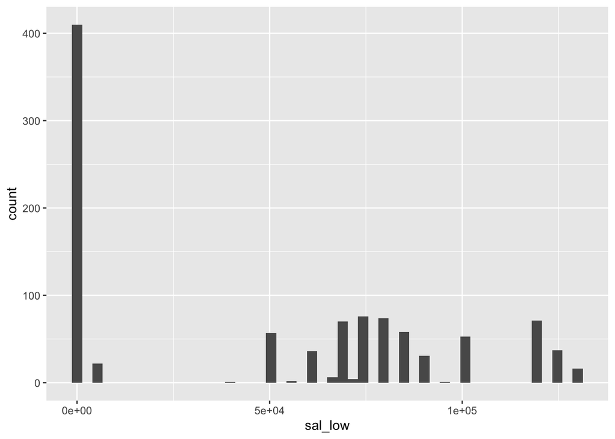

```r
#new data frame for exploring
jobs_clean <- jobs_salary

#making sal_low and sal_high numeric
jobs_clean$sal_low <- gsub("[$,]", "", jobs_clean$sal_low) |>
  sapply(as.numeric)
jobs_clean$sal_high <- gsub("[$,]", "", jobs_clean$sal_high) |>
  sapply(as.numeric)

#only rows with values for exploring
no_na_low <- jobs_clean[!is.na(jobs_clean$sal_low), ]

#plot histogram of all values
ggplot(no_na_low, aes(sal_low)) +
  geom_histogram(bins = 50)
```

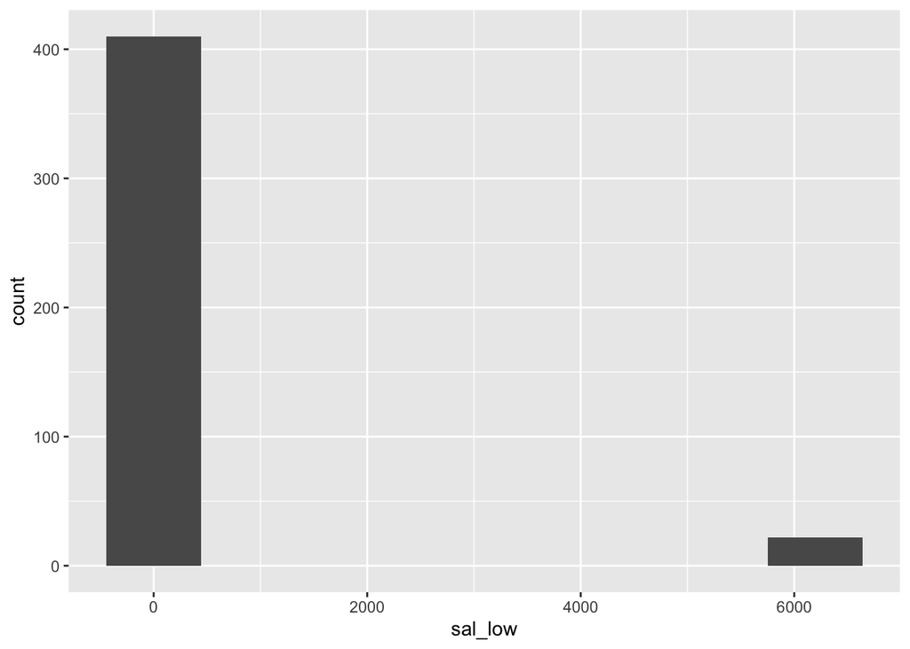

```r
#cut off the first group
sal_to_adjust <- no_na_low |>
  filter(
    sal_low < 25000
  )

#plot the first group
ggplot(sal_to_adjust, aes(sal_low)) +
  geom_histogram(bins = 8)
```

The distribution showing clear groups: below 1000 are hourly wages, above 5000 and below 7000 are monthly wages

```r
#sal_low less than 7000 and greater than 5000: x12
#sal_low less than 1000: x2080

#monthly conversion
sal_monthly <- jobs_clean |>
      filter(
        sal_low > 5000,
        sal_low < 7000
      ) |>
          mutate(
            sal_low = sal_low * 12,
            sal_high = sal_high * 12
          )

#hourly conversion
sal_hourly <- jobs_clean |>
      filter(
        sal_low < 1000
      ) |>
          mutate(
            sal_low = sal_low * 2080,
            sal_high = sal_high * 2080
          )

#non converted df
sal_correct <- jobs_clean |>
      filter(
        sal_low > 7000
      )

sal_na <- jobs_clean |>
      filter(
        is.na(sal_low)
      )

#stick together the fixed salaries data frame
jobs <- rbind(sal_monthly, sal_hourly, sal_correct, sal_na)

#peak at the data
glimpse(jobs)
```

```
## Rows: 2,845
## Columns: 26
## $ id                           <int> 903, 904, 905, 906, 907, 908, 909, 910, 9…
## $ key_field                    <int> 636, 637, 638, 639, 640, 641, 642, 643, 6…
## $ title                        <chr> "Data Analytics Analyst", "Data Analytics…
## $ company                      <chr> "SAMSUNG SDS", "SAMSUNG SDS", "SAMSUNG SD…
## $ onsite_remote                <fct> onsite, onsite, onsite, onsite, onsite, o…
## $ description                  <chr> "Responsibilities: • Analyze and scope re…
## $ salary                       <chr> "$5,800.00-$6,000.00", "$5,800.00-$6,000.…
## $ sal_low                      <dbl> 69600, 69600, 69600, 69600, 69600, 69600,…
## $ sal_high                     <dbl> 72000, 72000, 72000, 72000, 72000, 72000,…
## $ location                     <chr> "Plano, TX", "Plano, TX", "Plano, TX", "P…
## $ criteria                     <chr> "[{'Seniority level': 'Mid-Senior level'}…
## $ posted                       <chr> "2022-11-22", "2022-11-22", "2022-11-22",…
## $ link                         <chr> "https://www.linkedin.com/jobs/view/data-…
## $ skills                       <chr> " python , r , bachelor , master ,", " py…
## $ seniority                    <chr> "Mid-Senior level", "Mid-Senior level", "…
## $ etype                        <chr> "Contract", "Contract", "Contract", "Cont…
## $ jfunction                    <chr> "Information Technology", "Information Te…
## $ industries                   <chr> "IT Services and IT Consulting", "IT Serv…
## $ analyst_detail               <chr> "Data Analytics Analyst", "Data Analytics…
## $ analyst_detail_onsite_remote <lgl> FALSE, FALSE, FALSE, FALSE, FALSE, FALSE,…
## $ title_clean                  <fct> "Data Analytics Analyst", "Data Analytics…
## $ location_1                   <chr> "Plano", "Plano", "Plano", "Plano", "Plan…
## $ location_2                   <chr> "TX", "TX", "TX", "TX", "TX", "TX", "TX",…
## $ state.abb                    <chr> NA, NA, NA, NA, NA, NA, NA, NA, NA, NA, N…
## $ state                        <fct> TX, TX, TX, TX, TX, TX, TX, TX, TX, TX, T…
## $ city                         <fct> Plano, Plano, Plano, Plano, Plano, Plano,…
```

## Analysis

### Most requested skills

Here we determine the most requested skills (regardless of associated salary). Below is a list of the top 10 requested skills in our sample of job postings, where `count` indicates the number of job postings in our sample that mentioned this skill, and `perc` is the percentage of postings in our sample that mentioned this skill.

```r
top_10_skills <- jobs.skills |>
  group_by(value) |>
  summarize(count = n(),
            perc = n() / nrow(jobs)) |>
  arrange(desc(count)) |>
  head(10)

top_10_skills
```

```
## # A tibble: 10 × 3
##    value                  count  perc
##    <chr>                  <int> <dbl>
##  1 " r "                   2799 0.984
##  2 " sql "                 2214 0.778
##  3 " bachelor "            1436 0.505
##  4 " python "              1201 0.422
##  5 " communication "       1145 0.402
##  6 " tableau "             1071 0.376
##  7 " statistics "           939 0.330
##  8 " database "             924 0.325
##  9 " git "                  889 0.312
## 10 " data visualization "   682 0.240
```

The most requested skill to have is r , appearing in 98 percent of our job listings.

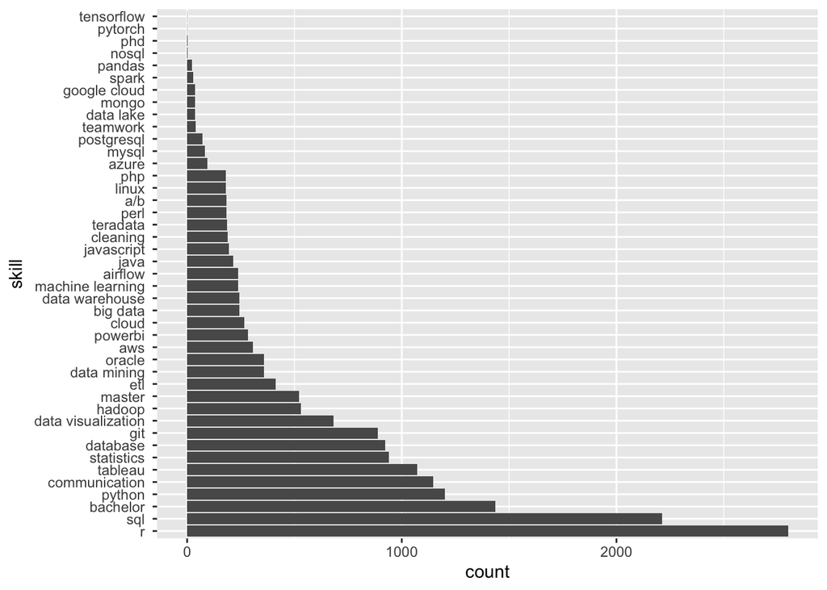

```r
fig2 <- ggplot(jobs.skills, aes(x = fct_infreq(value))) +
  geom_bar() +
  coord_flip() +
  labs(x = "skill")

fig2
```

Above is a comprehensive account of skills we found and their respective number of mentions.